# 260-2016-03-29

2016-03-28 09:29:15

## Prelude

[video not shown]

## Today's Topics

- Quiz 3
- Sensory systems
- Review Exam 2

## Sensation/Cognition/Action

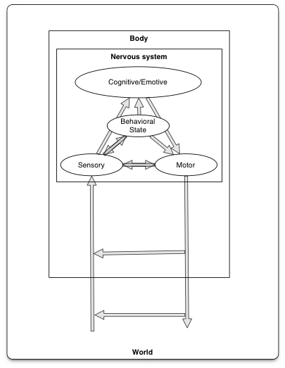

## From sensation to action

[figure not shown]

## Systems view

- Input
- Processing
- Memory
- Output

## You vs. Your Smartphone

[figure not shown]

## Multisensory processing in a smartphone

- Accelerometer
- Gyroscope
- Magnetometer
- Proximity sensor
- Ambient light sensor
- Barometer

http://www.phonearena.com/news/Did-you-know-how-many-different-kinds-of-sensors-go-inside-a-smartphone_id57885

## Multisensory processing in a smartphone

- Thermometer
- Mic
- Camera
- Radios (Bluetooth, wifi, cellular, GPS)

http://www.phonearena.com/news/Did-you-know-how-many-different-kinds-of-sensors-go-inside-a-smartphone_id57885

## Dimensions of sensory processing

- Interoceptive
  - How am I?
- Exteroceptive
  - What's in the world, where is it?

## Questions for interoception

- Tired or rested
- Well or ill
- Hungry or thirsty
- Stressed vs. coping
- Emotional state

## Questions for exteroception

- Who/What is out there?
- Where is it?

## Who/what

- Animate/inanimate
- Conspecific/non
- Threat/non
- Familiar/un
- Mate/non
- Food source/non

## Where

- Distance
- Elevation, azimuth
- Coordinate frames
  - Self/ego
  - Object
  - Allo/world
- Where moving?

## How

- What kind of response?
  - External
  - Internal
- Approach/avoid/freeze
- Signal/remain silent
- Manipulate

## More than 5 senses

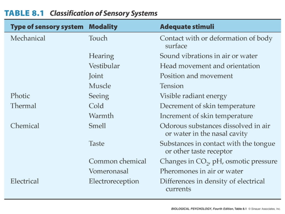

## How sensory channels differ

- What is the energy/chemical source
- How does the channel inform
  - What is out there
  - Where it's located

## Features of sensory signals

- Tonic (sustained) vs. phasic (transient) responses
- Adaptation
  - Decline in sensitivity with sustained stimulation
  - Most sensory systems attuned to change
- Information propagates at different speeds

## Common principles

- Sensors detect repeating signals
  - In space (textures)
  - In time

## Spatial frequency/contrast sensitivity

[figure not shown]

http://fourier.eng.hmc.edu/e180/lectures/figures/csf_image.gif

## Frequencies in sound

[figure not shown]

http://hearinghealthmatters.org/waynesworld/files/2012/06/Fourier-Analysis.gif

## Common principles

- Compare (>1) sensor for each channel
  - Eyes
  - Ears
  - Nostrils
  - Skin surface

## Why is the snake's tongue forked?

[figure not shown]

http://indianapublicmedia.org/amomentofscience/files/2010/06/tongue_111.jpg

## Common principles

- Sensory neurons have "receptive fields"
  - Area on sensory surface that when stimulated changes neuron's firing

## Tactile receptive field

[figure not shown]

## Visual receptive field

[figure not shown]

https://classconnection.s3.amazonaws.com/594/flashcards/1450594/png/untitled_picture51356035996428.png

## Common Principles

- Topographic maps

## Tonotopic (frequency) maps in auditory cortex

[figure not shown]

http://www.his.kanazawa-it.ac.jp/~tomi/public/MEGLab/Auditory/tonotopy.gif

## Retinotopic maps in visual cortex

[figure not shown]

http://jov.arvojournals.org/data/Journals/JOV/933499/jov-3-10-1-fig001.jpeg

## Common principles

- Non-uniform sensitivity

## Two-point touch thresholds

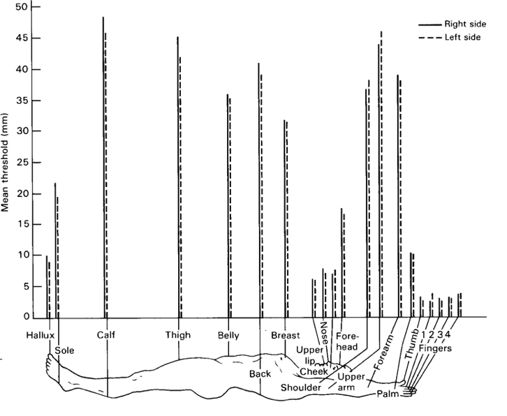

## Acuity variations across visual field

[figure not shown]

https://upload.wikimedia.org/wikipedia/commons/thumb/2/27/AcuityHumanEye.svg/270px-AcuityHumanEye.svg.png

## Hearing threshold varies across frequency

[figure not shown]

http://www.hearforever.org/userfiles/image/tools_to_learn/SS4_Hearing_Sensitivity.jpg

## Hierarchical processing

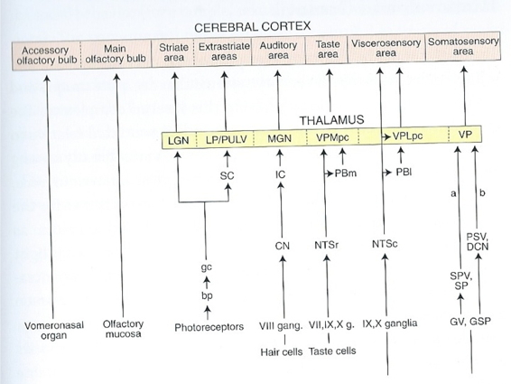

## Parallel processing

[figure not shown]

## Parallel processing

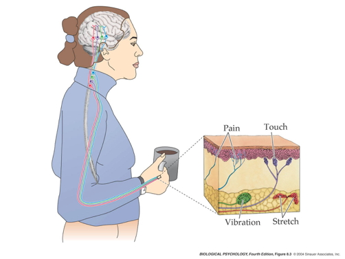

## Next time…

- Somatosensation